# Measuring the impact of Single Bed Rooms: A retrospective analysis for the New Hospitals Programme

Author

Andrew Hood, Sarah Lucas and Anya Ferguson

Published

2025-06-18

# Foreword

One of the key aims of the New Hospital Programme (NHP) is to ensure that every new hospital project builds on what we’ve learned from past ones. This includes not just the buildings themselves, but also how services are redesigned alongside them. This kind of shared learning hasn’t happened in a consistent way before, and the programme is committed to changing that. The NHP is also a chance to bring in new ideas and ways of working across the NHS – from how hospitals are designed to how care is delivered. It’s about scaling up innovation in a way that’s both joined-up and evidence-based.

Of course, trying new things always comes with risks as well as potential benefits. The challenge is to weigh these carefully and to use the evidence to guide and refine our decisions. Innovations are introduced based on what we know so far and are tested over time. This helps improve understanding and allows us to adjust or even completely rethink our approaches when needed.

One major policy decision by NHP has been to require that all new hospitals have 100% single bedded rooms. When this goal was set, the programme was clear that the evidence supporting it was limited – mainly based on theory and early experience from a few hospitals. Recognising this, NHP began detailed work to gather new data and use sophisticated analysis to assess the real impact of this change. The programme deserves credit for being open to new evidence and for its commitment to regularly reviewing and updating its policies. That flexibility is a real strength. By producing high-quality, publishable analysis and sharing the findings openly, the programme is leading by example - and using its unique position to make a meaningful contribution to the wider body of NHS knowledge.

This paper shares the latest findings on how single bedrooms are working in practice. Unsurprisingly, the results are mixed and far from conclusive. That’s partly because this is still early days – we’re only just starting to see how these designs perform at scale. At the same time, NHP has also carried out its first formal review of staff and patient experiences in new hospitals built over the last 10–15 years. That’s covered in a separate report, but it’s worth noting that many people shared their views on single rooms – and that feedback should be considered alongside this paper.

Overall, the current analysis shows that moving to 100% single rooms has benefits and drawbacks - these vary depending on the setting and how the design is implemented. What’s clear is that single rooms are not a guaranteed fix. The details and context really matter. Getting it right requires thoughtful design and a close eye on costs and trade-offs. Going forward, the programme should build on its commitment to researching what works best - and stay open to adjusting its approach based on real-world feedback and new evidence. That openness will be key to making sure innovations like adopting 100% single-bedded rooms genuinely improve care in new hospitals.

*(Peter Spilsbury, Strategy Unit Director)*

This work, analysis and report have been a team effort. The following people have made a material contribution to all or part of the development of this work and the various outputs:

**Strategy Unit** - Peter Spilsbury, Simon Bourne, Jacqueline Grout, Jennifer Wood.  
**New Hospitals Programme** - Cheryl Riotto, Anne White, Joanna Wood, Carolyn Akyil, Dr. Michael Weinbren.  
**NHS England** - Joshua Igbineweka, Paul Smith

# Executive Summary

Traditionally, hospital beds have been in multi-bed bays, however, there has been a move towards single occupancy inpatient rooms. Numerical evidence on the impact of single rooms is limited. We sought to quantify the potential impacts of switching to single-bed accommodation to help inform the planning and design of future hospitals.

We used causal impact analysis to quantify the change in productivity and efficiency measures (length of stay, waiting time, bed occupancy, emergency readmissions, cleaning costs), health and safety measures (in-hospital deaths, in-hospital falls and injuries, hospital acquired c.difficile), and patient and staff experience (Friends and Family Test for inpatient experience, staff survey, staff sickness and staff turnover) in 7 study hospitals in the English National Health Service that switched to entirely or majority single-bed rooms between 2010 to 2022, with the use of comparable control hospitals.

There was significant variability following switching to single rooms both within measures and between hospitals - mixed findings that are broadly in line with the published literature and also feedback from an independent listening exercise with representatives from these hospitals.

For bed occupancy, emergency readmissions, cleaning costs and all health and safety measures there were either positive effects or no change. However, positive, negative and no effects were seen for length of stay, waiting time, patient experience, and staff experience measures. Where there were immediate positive *or* negative impacts on a metric, these often regressed back towards prior levels over the longer-term (2 years).

Reduced length of stay could potentially help offset additional costs associated with single room hospitals, however, at general acute hospitals there was no significant change in length of stay (7% reduction (-17% to 2% 95% CI)). At general acute hospitals the patient experience increased signficantly by 1% (+0.1% to +2% 95% CI); the proportion of staff recommending their trust as a place to work significantly decreased by 15% (-23% to -6% 95% CI) and staff sickness absences increased by 6% (1% to 12% 95% CI).

For planning purposes, the NHP may want to take a more conservative approach to modelling the impact on LoS of SBR but also consider other potential efficiency gains i.e. reduced waiting times, reduction in falls/injuries and infections. Additionally, acknowledging the potential adverse impacts on staff experiences, qualitative monitoring of impacts would aid in implementation and mitigation strategies.

For both SBR impacts and broader programme evaluation, a prospective monitoring framework of these indicators and more would support and develop the evidence-base for hospital design and builds in the future.

# Introduction and background

Since it’s inception, the New Hospital Programme (NHP) has advocated for single bed rooms (SBR). The grounds for this are based on a range of guidance, evidence and previous policy statements of intent. Whilst that position is unequivocal, there is uncertainty around the quantification of impacts of such a change and thus the assumptions that feed into demand and capacity models and economic business cases for current and future new hospital developments.

Specifically, a starting assumption was that a length of stay reduction of 12% was likely for all new SBR facilities compared to prior trends. This assumption was criticised by the national audit office (NAO) (National Audit Office 2023) in the face of a mixed evidence base.

It is the express aim of this analysis therefore to quantify the range of likely impacts for length of stay and a basket of other measures across patient & staff experience, productivity & efficiency and health & safety. Where there are differential impacts, i.e. for specialist units compared to general acute, these will also be highlighted to aid future planning assumptions.

# Analytical scope

There are 7 hospitals in England where single-bed inpatient accommodation replaced multi-bed accommodation fully or in part. We have used these hospital sites as natural experiments, and with the use of matched control sites are able to quantify changes in these study sites following their switch to single bedrooms.

Our analysis investigates the impact on 12 measures across three domains 1) Health and Safety, 2) Patient and Staff Experience and 3) Productivity and Efficiency to determine the likely extent of any benefits, or negative impacts that need to be mitigated with single-bed room hospital sites.

# What we already know on impacts

There have been 2 NHP commissioned pieces of work in the recent past aiming to better understand the nature and scale of any impacts related to switching from multi-occupancy hospital rooms to single-bed rooms.

The Health Economics Unit undertook a literature review (Health Economics Unit 2022) primarily around clinical impacts, patient/staff experience and the economic impacts of the structural changes. Using evidence from the literature the review highlighted the following factors that may potentially be impacted in some way:

- Mortality
- Complications of disease
- Healthcare Acquired Infections (HCAI)
- Falls and patient safety
- Readmissions
- Privacy
- Loneliness
- Disturbance
- Quality of Life
- Length of stay
- Costs of care

The conclusions of the review were that **“moving adult and child inpatients from older hospitals with largely shared rooms to fully single-room accommodation is unlikely to lead to a meaningful difference in clinical outcomes, may reduce overall costs per patient, and will lead to greater satisfaction in a majority of patients. However, switching to 100% single rooms will leave a substantial minority of people feeling lonely and socially isolated, with many patients preferring to be in a shared room. A compromise approach – where accommodation is largely in single rooms but includes some bays with two to four beds – may provide maximum satisfaction and minimise overall costs without adversely affecting clinical outcomes.”**

More latterly, the Innovations team at NHP have created a living evidence review (Wood 2024) on the topic to identify new and emerging evidence of effects of implementing single bedrooms and their potential scale. The review highlighted the ongoing variable nature of impacts with both positive, negative and neutral impacts found across length of stay, mortality, patient experience and staff attitudes.

Broadly speaking, the evidence points towards an increase in falls/fall risk, improved infection control and increased patient satisfaction with admitted care. More positive outcome impacts were generally demonstrated for specific clinical subgroups of patients notably intensive care; maternal and neonates; oncology.

The review summary suggests that **“Overall, 87% of studies analysed by Taylor et al., 2018 reported advantages associated with single patient rooms. Of these, 27% reported a combination of advantages and disadvantages, while 22% of the studies reported a combination of advantages and neutral results.”**

In parallel with this work, colleagues at the Strategy Unit undertook a qualitative look-back exercise (J Wood 2025) with some previous new hospital schemes that were the same as our study sites. Though there were no specific views sought on single-bedded rooms, representatives of those schemes proactively identified SBR as either facilitating improvements or inducing challenges to ways of working.

In the feedback from schemes, there were felt to be generally positive impacts on patient experience & recovery and infection control, but additional challenges for staff around time efficiency and observation practices including risks of out-of-sight events.

# Hospital Background

Initially 11 hospitals were identified to have made a switch to single bedrooms. However due to being unable to access data for hospitals outside England, three hospitals (Ulster Hospital, Glasgow Central and The Grange Hospital) were excluded from this analysis. James Paget hospital made a switch to single bedrooms in May 2023 but was also excluded from analysis, due to the switch being too recent and that currently the ward is used as interim beds for RAAC remedial work.

An overview of the remaining seven hospitals that switched to SBR is shown in Table 1. Data on the percentage of single bedrooms before and after the switch at each site was not readily available or inconsistent, so an indication of whether the switch was partial or full is shown. Plots of the percentage of single bedrooms at provider level calculated from two different data submissions are available in Appendix E (Section 12.5).

Table 1: Details of the switch to single bed accommodation at the seven intervention sites.

| Site | Provider | Switch month | Type of switch |
| --- | --- | --- | --- |
| Royal Liverpool | Liverpool University Hospitals NHS Foundation Trust | Oct 2022 | full |
| Clatterbridge Cancer Centre | The Clatterbridge Cancer Centre NHS Foundation Trust | Jun 2020 | full |
| Royal Papworth | Royal Papworth Hospital NHS Foundation Trust | May 2019 | full |
| Chase Farm Hospital | Royal Free London NHS Foundation Trust | Sep 2018 | partial |
| Southmead Hospital | North Bristol NHS Trust | May 2014 | partial |
| Tunbridge Wells | Maidstone and Tunbridge Wells NHS Trust | Jan 2011 | full |
| Peterborough (city) Hospital | North West Anglia NHS Foundation Trust | Nov 2010 | partial |

n: 7

[interactive chart not shown]

Location of 7 natural experiment sites in England

## Royal Liverpool University Hospital

Royal Liverpool University Hospital is a large acute hospital. It mainly focuses on complex planned care and specialist services including nephrology, renal transplantation, nuclear medicine, haematology, lithotripsy, dermatology and urology (Liverpool University Hospitals 2024). The provider Liverpool University Hospitals NHS Foundation also manages Aintree University hospital and Broadgreen hospital. Royal Liverpool University Hospital moved to a new site with fully single bed accommodation in October 2022.

## Clatterbridge Cancer Centre

The Clatterbridge Trust operates 3 cancer centres in the Cheshire and Merseyside area. The Liverpool centre moved to fully single-bed rooms in June 2020. The centre offers the full range of cancer treatment, both routine and surgical as well as diagnostics, outpatient appointments and associated support services (Clatterbridge Cancer NHS Trust 2024).

## Royal Papworth

Royal Papworth hospital is a specialist centre for cardiothoracic (heart and lung) treatment, surgery and transplantation (Royal Papworth Hospital 2024). The move to fully single bed accommodation occurred in May 2019.

## Chase Farm

Chase Farm hospital is a planned care centre operated by the Royal Free London NHS Trust. The Trust also runs the Royal Free and Barnet Hospital sites as well as other acute service across greater London (Royal Free London 2024). The new-build Chase Farm site, opened in September 2018 with a total of 50 beds, 42 were single bed rooms (Flint 2018).

## Southmead

Southmead hospital is run by the North Bristol NHS Trust who also operate Frenchay and Cossham Hospitals as well as other acute and rehabilitation services. The Brunel building housing the hospital opened in May 2014 with three quarters of the beds in single rooms and the remainder in four-bed bays (North Bristol NHS Trust 2024).

## Tunbridge Wells

The new hospital at Tunbridge Wells, replacing services at Pembury and Kent & Sussex, opened in two phases in January 2011 (maternity and children) and September 2011 (other inpatient services). Tunbridge Wells was the first hospital in England to switch to fully single bedroom accommodation. (Jill Maben 2014)

## Peterborough

Peterborough City Hospital, operated by North West Anglia NHS Trust, was opened in November 2010 offering a range of acute and specialist services (North West Anglia 2024). The site opened with a mix of single bedrooms and three- to four-bedded ward areas.

# Impact measures and data sources

The evidence suggests that impacts can be broadly categorised into three domains: health & safety, staff & patient experience and productivity & efficiency. A long list of potential impacts were drawn from the existing evidence reviews and measures were sought from published data that were specific to the logic/causal relationship or were proxies for the suggested effect. Measures were included within the study if there were sufficient time series, if the data were consistent and if the data were available at least at provider level.

Where existing data sources were lacking, and for those impacts based on hospital data, we derived suitable measures from Secondary User Service (SUS) data held within NCDR (Arden GEM CSU, n.d.).

Our final set of impact measures are thus:

Table 2: Information on indicator source, provenance, derivation and rationale.

| id | domain | name | desc | source | derivation_notes | rationale |
| --- | --- | --- | --- | --- | --- | --- |
| 1 | Health and Safety | Hospital deaths | Rate of death per 1,000 discharges. | Derived from SUS admitted patient care data (NCDR) | Ordinary inpatient only. Stillbirth excluded. NHS providers only. | Patients could miss out on informal observations by both staff and other patients thus missing critical changes in symptoms. Whilst there is mixed evidence of SBR impacts on mortality, several studies… |
| 2 | Health and Safety | Healthcare Associated Infections - clostridium difficile | Cases per 10,000 bed days | https://www.gov.uk/government/collections/healthcare-associated-infections-hcai-guidance-data-and-analysis | Bed days denominator derived from SUS APCE | Single bed rooms remove other patients as vectors for transmitting infectious pathogens. The WHO have concluded that single rooms reduce HCAI. |
| 3 | Health and Safety | Falls and injuries | Spells with fall as % of all spells | Derived from SUS admitted patient care data (NCDR) | Distinct spells where episode order in spell > 1 AND ICD-10 code in (W01, W03-W08, W18-W19, S0-S9, T0, T10-T14) where non present in first episode. | Single rooms with greater volume of equipment, more 'wet space' and lower levels of casual observation may increase the risk of patient falls and injuries. |
| 4 | Productivity and Efficiency | Length of Stay | Mean length of stay | Derived from SUS admitted patient care data (NCDR) | Ordinary inpatient only, deaths excluded, completed spells only, NHS providers only. | Privacy and improved sleep can lead to quicker recovery and therefore reduced length of stay in single bed rooms for some patients. Higher-quality research suggests shorter hospital stays are likely. |
| 5 | Productivity and Efficiency | Waiting time | Median wait time in weeks | https://www.england.nhs.uk/statistics/statistical-work-areas/rtt-waiting-times |  | Logically, shorter length of stay and greater flexibility of bed stock (occupancy) mean that waiting lists and times are likely to reduce all other things equal. |
| 6 | Productivity and Efficiency | Emergency readmissions | % of discharges with emergency readmission < 30 days | Derived from SUS admitted patient care data (NCDR) | Ordinary inpatient only, discharge method = 1 or 3 | Evidence is scarce for the direction and scale of impacts on readmission with some studies citing an increase others a decrease for patients of different types. |
| 7 | Productivity and Efficiency | Bed occupancy | % available beds occupied overnight | https://www.england.nhs.uk/statistics/statistical-work-areas/bed-availability-and-occupancy/ |  | Single bed rooms are thought to offer more flexibility in use of bed stock - single rooms can be closed due to infectious incidents for example rather than whole wards making management of emergency c… |
| 8 | Productivity and Efficiency | Cleaning costs | Total cleaning costs (£/sqm of occupied floor space) | https://digital.nhs.uk/data-and-information/publications/statistical/estates-returns-information-collection |  | Single ensuite rooms mean both more wet areas to clean and more movement of equipment and personnel between rooms. Evidence suggests day-to-day management costs of single beds is greater. |
| 9 | Patient and Staff Experience | Patient experience | Family and friends test, % positive scores (inpatient) | https://www.england.nhs.uk/fft/friends-and-family-test-data/ |  | Some patients prefer the privacy and lack of disturbance from single rooms whilst others prefer the social interaction of shared space. There is mixed evidence around patient satisfaction resulting fr… |
| 10 | Patient and Staff Experience | Staff sickness | % available days taken off sick | https://digital.nhs.uk/data-and-information/publications/statistical/nhs-sickness-absence-rates/august-2023-provisional-statistics |  | Fewer multi-patient exposures and additional infection control steps may lead to decreased staff absence from illness. |
| 11 | Patient and Staff Experience | Staff turnover | % of staff leaving | https://digital.nhs.uk/data-and-information/publications/statistical/nhs-workforce-statistics |  | Linked to staff experience, the rate of staff leavers may increase with increased disatisfaction at work. |
| 12 | Patient and Staff Experience | Staff experience | % staff recommending the trust as place to work | https://www.nhsstaffsurveys.com/results/ |  | Recent studies suggest that staff have strong reservations about single rooms related to stress and personal safety. |

n: 12

## Availability of indicators over time and for each site

Figure 1 demonstrates the availability of indicator datasets over time and the month of the switch to SBR for the seven study sites to allow for general assessment of suitability for testing.

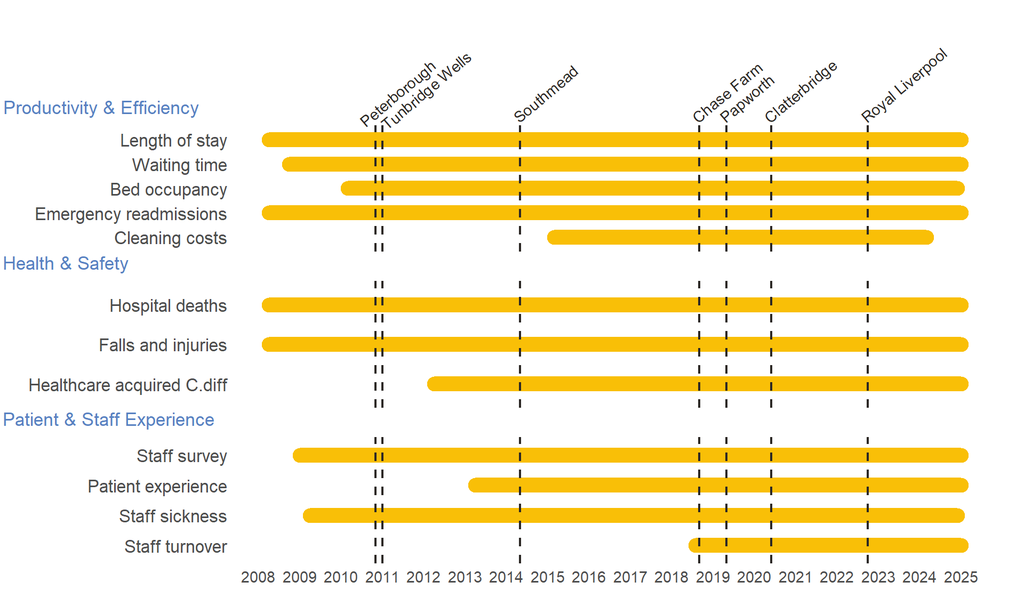

Figure 1: Availability of indicators over time. Dashed lines represent the month of the switch to SBR in each intervention site.

Additional data issues have been uncovered during preparation of the data for analysis and some further omissions of some indicator/site combinations have been made. Full notes on data availability and suitability in relation to the analysis can be found in Appendix B (Section 12.2).

Table 3 summarises which indicators have been been investigated for each site, and where analyses were not possible due to lack of data, other data issues or inability to fit a suitable model to the data.

Table 3: Summary of indicators that were investigated for each site.

| Variable | Level | Royal Liverpool | Clatterbridge | Papworth | Chase Farm | Southmead | Tunbridge Wells | Peterborough |
| --- | --- | --- | --- | --- | --- | --- | --- | --- |
| Productivity & Efficiency |  |  |  |  |  |  |  |  |
| Length of stay | Site | ✔ | ✔ | - | ✔ | ✔ | ✔ | ✔ |
| Waiting time | Provider | ✔ | ✔ | ✔ | - | - | ✔ | ✔ |
| Bed occupancy | Provider | ✔ | ✔ | - | ✔ | ✔ | x | x |
| Emergency readmissions | Site | ✔ | ✔ | ✔ | ✔ | ✔ | ✔ | ✔ |
| Cleaning costs | Site | ✔ | ✔ | ✔ | - | x | x | x |
| Health & Safety |  |  |  |  |  |  |  |  |
| Hospital deaths | Site | ✔ | ✔ | - | - | ✔ | ✔ | ✔ |
| Falls and injuries | Site | ✔ | - | - | - | ✔ | ✔ | ✔ |
| Healthcare acquired C.diff | Provider | ✔ | - | - | ✔ | ✔ | x | x |
| Patient & Staff Experience |  |  |  |  |  |  |  |  |
| Patient experience | Site | ✔ | ✔ | ✔ | ✔ | ✔ | x | x |
| Staff sickness | Provider | ✔ | ✔ | ✔ | ✔ | ✔ | ✔ | ✔ |
| Staff turnover | Provider | ✔ | ✔ | ✔ | x | x | x | x |
| Staff survey | Provider | ✔ | ✔ | ✔ | ✔ | ✔ | ✔ | x |

✔ indicates there was sufficient/suitable data to conduct causal impact analysis.'x' indicates that there was not sufficient time series data available to analyse.'-' indicates data issues that meant it was not possible to conduct causal impact analysis.

For some sites (i.e Chase Farm, Clatterbridge and Papworth) at least part of the outcome period is impacted by COVID-19. While COVID-19 effects will also be present in the matched control sites, the magnitude of effects varies greatly between hospitals. Indeed, for some measures Papworth was excluded as it appears to have been impacted to a much greater degree by COVID-19 than its control sites.

Where there is missing data or anomalies in the outcome periods, i.e. sudden increases or decreases, the outcome period has been cut short. For the Health and Safety indicators the rates of these adverse events were generally low at the specialist sites (Papworth, Clatterbridge and Chase Farm), often dropping to zero in some months, which meant it was not always possible to fit a suitable causal impact model.

Some data is only available at a provider level, this means that where the switch to single bedrooms occurred at a provider with multiple sites the effects of the switch will be diluted by the lack of the change in single bedroom percentage at the providers other sites.

# Description of methods

Causal Impact Analysis is a technique that uses a control group to estimate the post-intervention counterfactual against which to measure study group impacts (Broderson K 2015). The relationship between the control group (similar hospital providers, patient case-mix and prior trends) and the study site pre-switch is determined and used along with the control sites data post-switch to calculate a synthetic baseline that predicts what would have happened to the outcome of interest at the study site had there been no switch. We can then compare this synthetic baseline with the actual outcome at the site of interest to quantify the change in the study hospitals following their switch to single-bed rooms.

## Finding control hospitals

There was a multi-phase selection process to create a pool of controls for each study site. A summary of these steps is presented in Figure 2. The first step was to match the study site and controls on type of site. For Clatterbridge the pool was limited to cancer-only sites and for Royal Papworth the pool was limited to cardiac sites. For all other study sites the pool was limited to general acute sites.

Controls were then matched on the percentage of single bed rooms available at the provider prior to the switch. Providers were excluded if the difference between their SBR percentage and the study’s provider was greater than 5% in the month before the switch to SBR. Then providers were excluded if their SBR percentage increased by 5% or more after this point.

Differences in floor space, the median age of inpatients and the elective:non-elective ratio of admissions were calculated between the controls and study sites and ranked. A similarity rank was calculated by ranking the sum of these three ranks and sites with a similarity rank less than or equal to 20 formed the control pool for further analysis. Due to Clatterbridge and Royal Papworth being specialist trusts, there were only 4 and 9 sites respectively in the control pools.

[interactive chart not shown]

Figure 2: Flow chart of the multi-phase process used to select the top 20 controls for each site. *The similarity rank is calculated as the sum of the ranked difference of floor space, median age of patients and the elective:non-elective ratio of admissions.

A full list and map of the sites in the control pools for each study site can be found in Appendix C (Section 12.3).

## Causal Impact Analysis

The causal impact analysis is implemented using the `MarketMatching` (Larsen 2024) package in R , which uses the `dtw` (Giorgino 2022) and `CausalImpact` (Brodersen and Hauser 2014) R packages to provide a simple way to find the most appropriate control matches using dynamic time warping and then using these controls for causal impact analysis using Bayesian structural time-series models. Using control sites means that seasonal changes are accounted for within the analysis. The dynamic time warping approach prevents potential controls being excluded if their relationship with the study site is temporarily shifted; it accounts for any shifts in any historic trends, such as a winter peak starting slightly earlier or later at a potential control site.

Following the multi-phase control selection process outlined in Section 8.1, the control pools for each site were fed into the `MarketMatching` package. This step selects the best matched control sites based on them having similar trends in the variable of interest over time to the study site. Up to 5 control sites were selected for each study site, but for some sites, particularly the specialist centres, the number of appropriate matches was smaller and so fewer than 5 control sites were selected. Control sites are selected for each site and indicator variable and as this matching of controls is based on similar trends over time a study site may have different control sites selected for different indicators. A list of the control providers/sites identified by `MarketMatching` for each indicator can be found in Appendix D (Section 12.4).

The causal impact models were generated for each site and for each indicator where sufficient data was available to fit a model and there was at least 1 year of outcome period. Where possible a 2-year outcome period was used. Ideally at least a 2-year baseline period would have been used, but to maximise the number of sites we could include a shorter baseline period was used if an appropriate model could be fitted to the data. The Mean Absolute Percentage Error (MAPE) and Durbin-Watson statistic of the models were checked, and the prior local level standard error adjusted if required to ensure a good historical model fit while minimising the forecasting intervals.

## Aggregate (meta) analysis

Where possible, for each indicator variable a meta-analysis was conducted using the data for district general and acute hospitals. The specialist hospital sites were excluded from this analysis as it is felt the effects at these sites may not be generalisable when considering future building of general acute hospitals.

A random-effects meta-analysis was conducted using the `metafor` R package (Viechtbauer 2024), and the relative effects for each site weighted using the inverse variance, as used for meta-analysis of causal impact models by Schmitt et al. (Schmitt, Tull, and Atwater 2017).

# Main results

## Interpreting the causal impact analysis

Plots for each causal impact model are shown in appendix A (Section 12.1). These plots are made up of three graphs, with the time point of the switch shown in red.

For example:

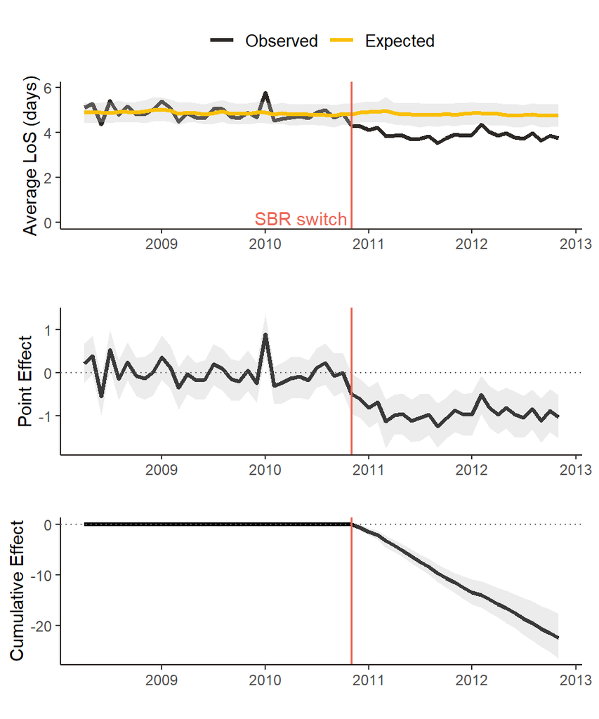

1. Expected value of the indicator in the outcome period (yellow), compared to the actual values of the study site (black).
2. The point estimate shows the difference between the expected values and actual values at each time point, so at time points where the posterior intervals do not include zero there is a significant difference.
3. Cumulative difference between the expected and actual values over the outcome period. Our measures are typically rates and percentages, which are not additive over time like count data would be, so the cumulative effect can not always be meaningfully interpreted. Also, the cumulative difference cannot always be compared across sites, due to data issues resulting in differing lengths of outcome period.

Where there are results for 2 or more general acute hospitals a second forest plot shows the effects for just these general acute hospitals, alongside the mean value calculated in the meta-analysis. In this case the size of points indicates the weight that each site has been given in the analysis; those with the smallest credible intervals are given the greatest weight in calculating the mean.

**Results tables** give the average values over the outcome period. They give the actual value for the study site in the outcome period, the predicted value had no change in single bedrooms occurred, and the absolute effect, which is the difference between the actual and predicted value. The relative effect size is a proportional change relative to the predicted value.

For example, Peterborough hospital was predicted to have an mean length of stay in the outcome period of 4.8 days, however, following a switch to single bedrooms the actual mean length of stay was 3.9 days. This is an absolute difference between predicted and actual values of 0.9 days, which equates to a 19% reduction in mean length of stay compared to predicted values.

Some of our indicators are rates, so the percentage change is a change in a rate. For example, a 10% decrease in emergency readmissions following a switch to single bedrooms means that if the predicted emergency readmission rate was 20% for a hospital with multi-bed bays, the emergency readmission rate for a single bedroom hospital would be expected to be 18%.

It is assumed the effects have stabilised within the 2 year outcome period so that the average relative effect in the outcome period is reflective of the true ongoing effect at any point in time. The indicators used are generally rates and percentages so any changes are not applied cumulatively. Interpretation of median waiting time is more complex; it is possible there may be cumulative impacts as a result of sustained changes in productivity affecting waiting list size.

## Productivity and Efficiency

### Length of stay

Mean length of stay (in days) significantly decreased at 3/6 sites (Southmead, Peterborough and Chase Farm), was unchanged at 2/6 sites (Royal Liverpool and Tunbridge Wells), but significantly increased at Clatterbridge.

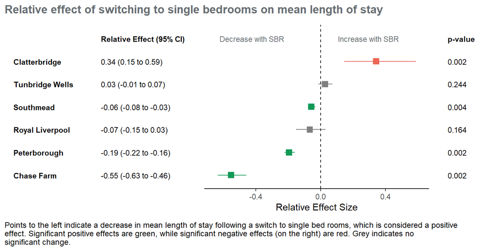

| Average effects of switching to single bedrooms on mean length of stay Site | Average effects of switching to single bedrooms on mean length of stay Actual Effect | Average effects of switching to single bedrooms on mean length of stay Predicted Effect (95% CI) | Average effects of switching to single bedrooms on mean length of stay Absolute Effect (95% CI) | Average effects of switching to single bedrooms on mean length of stay Relative Effect (95% CI) | Average effects of switching to single bedrooms on mean length of stay p-value | Average effects of switching to single bedrooms on mean length of stay Significance |
| --- | --- | --- | --- | --- | --- | --- |
| Clatterbridge | 10.11 | 7.59 (6.37 to 8.83) | 2.53 (1.29 to 3.75) | 0.34 (0.15 to 0.59) | 0.002 | Sig Increase |
| Tunbridge Wells | 3.42 | 3.33 (3.19 to 3.46) | 0.09 (-0.05 to 0.23) | 0.03 (-0.01 to 0.07) | 0.244 | Non-sig |
| Southmead | 4.52 | 4.78 (4.66 to 4.9) | -0.27 (-0.39 to -0.15) | -0.06 (-0.08 to -0.03) | 0.004 | Sig Decrease |
| Royal Liverpool | 4.99 | 5.36 (4.84 to 5.88) | -0.37 (-0.89 to 0.15) | -0.07 (-0.15 to 0.03) | 0.164 | Non-sig |
| Peterborough | 3.88 | 4.82 (4.62 to 4.98) | -0.94 (-1.1 to -0.74) | -0.19 (-0.22 to -0.16) | 0.002 | Sig Decrease |
| Chase Farm | 2.67 | 6.02 (4.92 to 7.3) | -3.35 (-4.62 to -2.25) | -0.55 (-0.63 to -0.46) | 0.002 | Sig Decrease |

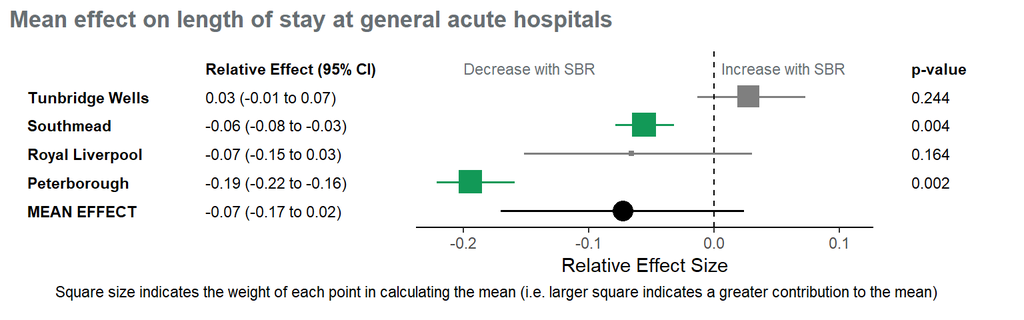

The effect on length of stay was highly variable with Chase Farm (an elective care site) having a 55% reduction in length and Clatterbridge (a cancer centre) having a 34% increase (Section 12.1.1). At the general acute hospitals the change in average length of stay varied from a 3% increase (equivalent to 0.1 days) at Tunbridge Wells to a significant 19% decrease (equivalent to 0.9 days) at Peterborough. The mean effect at general acute hospitals was a non-significant 7% reduction in length of stay.

### Median waiting time

The median referral to treatment waiting time (in weeks) significantly decreased at 2/5 sites (Royal Liverpool and Peterborough), was unchanged at 2/5 sites (Papworth and Clatterbridge) and increased at Tunbridge Wells.

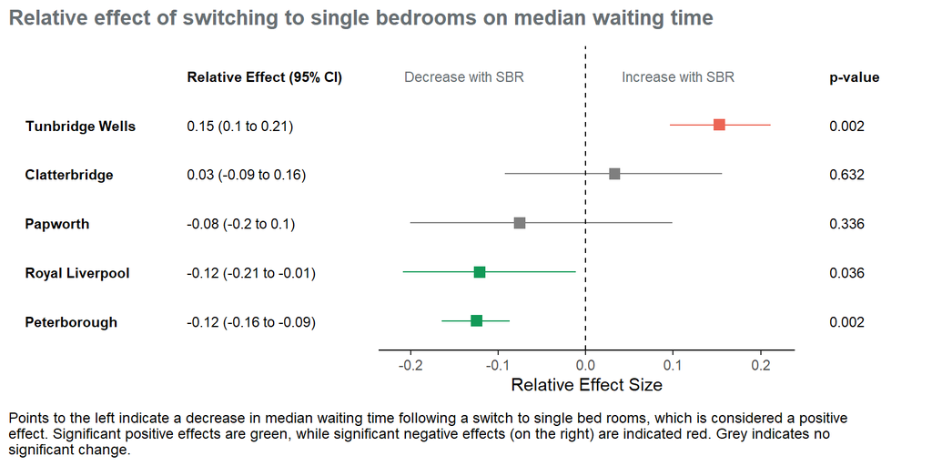

| Mean effect on median waiting time at general acute hospitals Site | Mean effect on median waiting time at general acute hospitals Actual Effect | Mean effect on median waiting time at general acute hospitals Predicted Effect (95% CI) | Mean effect on median waiting time at general acute hospitals Absolute Effect (95% CI) | Mean effect on median waiting time at general acute hospitals Relative Effect (95% CI) | Mean effect on median waiting time at general acute hospitals p-value | Mean effect on median waiting time at general acute hospitals Significance |
| --- | --- | --- | --- | --- | --- | --- |
| Tunbridge Wells | 5.46 | 4.74 (4.51 to 4.98) | 0.72 (0.48 to 0.95) | 0.15 (0.1 to 0.21) | 0.002 | Sig Increase |
| Clatterbridge | 6.00 | 5.83 (5.19 to 6.61) | 0.17 (-0.61 to 0.81) | 0.03 (-0.09 to 0.16) | 0.632 | Non-sig |
| Papworth | 8.38 | 9.12 (7.62 to 10.47) | -0.74 (-2.1 to 0.76) | -0.08 (-0.2 to 0.1) | 0.336 | Non-sig |
| Royal Liverpool | 16.33 | 18.63 (16.52 to 20.64) | -2.3 (-4.3 to -0.18) | -0.12 (-0.21 to -0.01) | 0.036 | Sig Decrease |
| Peterborough | 4.33 | 4.95 (4.75 to 5.18) | -0.62 (-0.85 to -0.41) | -0.12 (-0.16 to -0.09) | 0.002 | Sig Decrease |

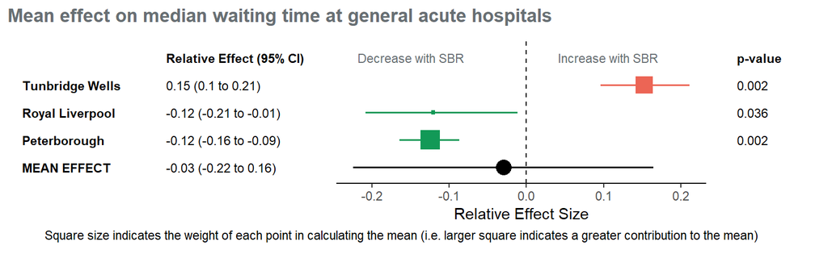

The effect on median waiting time varied from a 12% reduction to a 15% increase. Both Royal Liverpool and Peterborough had a 12% reduction in median waiting time, which equated to a decrease from 18.6 wks to 16.3 wks at Royal Liverpool and from 5 wks to 4.3 wks at Peterborough. The mean effect at general acute hospitals was a non-significant 3% reduction in median waiting time.

At Peterborough median waiting time dropped and was then relatively stable for the 2-year outcome period suggesting there was a fixed effect and that median waiting time would be unlikely to drop further over time as a result of the switch to single bedrooms (Section 12.1.2).

Median waiting time significantly increased at Tunbridge Wells, but this effect appeared to only be temporary during the first year post-switch as during the second year of the outcome period the waiting times fall back in line with the expected values. The switch to single bedrooms at Tunbridge Wells started in Jan 2011, which is the date we have used in our analysis, but occurred in stages between Jan and Sept 2011, so the differences seen in the first year could be due to disruption of services while the hospital was in a transition period.

### Bed occupancy

Bed occupancy is measured quarterly and is only available at provider level. The percentage of available beds occupied significantly increased at 2/4 sites (Clatterbridge and Southmead) and was unchanged at 2/4 (Royal Liverpool and and Chase Farm). An increase in bed occupancy is generally considered a positive result as it indicates a hospital is able to make greater use of its beds, as a result of not needing to leave beds empty to prevent spread of infection or maintain single sex wards. However, if bed occupancy is too high it can be considered negative as it indicates a potential lack of capacity and this can result in an increase in Emergency department waiting times as there are not sufficient beds to admit patients when required. We have not looked at Emergency department waiting times. However, Chase Farm only does elective care and Clatterbridge is a cancer centre, and so neither of these sites have Emergency departments.

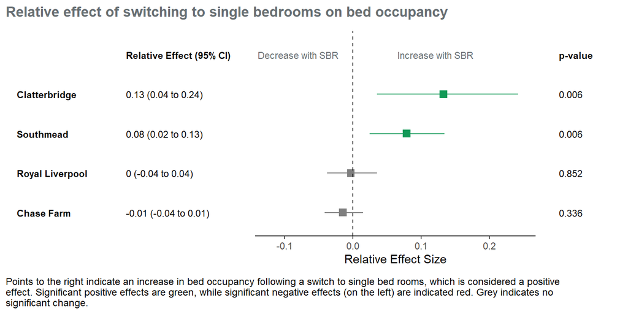

| Average effects of switching to single bedrooms on % of bed occupancy Site | Average effects of switching to single bedrooms on % of bed occupancy Actual Effect | Average effects of switching to single bedrooms on % of bed occupancy Predicted Effect (95% CI) | Average effects of switching to single bedrooms on % of bed occupancy Absolute Effect (95% CI) | Average effects of switching to single bedrooms on % of bed occupancy Relative Effect (95% CI) | Average effects of switching to single bedrooms on % of bed occupancy p-value | Average effects of switching to single bedrooms on % of bed occupancy Significance |
| --- | --- | --- | --- | --- | --- | --- |
| Clatterbridge | 74.33 | 65.77 (59.85 to 71.82) | 8.56 (2.52 to 14.48) | 0.13 (0.04 to 0.24) | 0.006 | Sig Increase |
| Southmead | 93.19 | 86.47 (82.19 to 90.98) | 6.73 (2.21 to 11) | 0.08 (0.02 to 0.13) | 0.006 | Sig Increase |
| Royal Liverpool | 95.19 | 95.45 (91.97 to 98.96) | -0.27 (-3.77 to 3.22) | 0 (-0.04 to 0.04) | 0.852 | Non-sig |
| Chase Farm | 85.25 | 86.51 (84.02 to 88.92) | -1.26 (-3.67 to 1.23) | -0.01 (-0.04 to 0.01) | 0.336 | Non-sig |

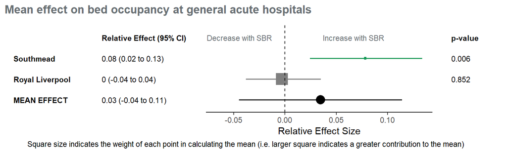

Bed occupancy was either unchanged or increased by up to 13%. The mean effect at the two general acute hospitals was a non-significant 3% increase in bed occupancy.

At Southmead, bed occupancy increased 8%; it was predicted to be on average 86% in the outcome period but an increase to 93% bed occupancy was seen (Section 12.1.3). It is perhaps unsurprising there was no significant increase in bed occupancy at the Royal Liverpool as based on historic trends bed occupancy was already predicted to be over 95%, leaving little scope to increase this.

### Emergency readmissions

The percentage of admissions that are emergency readmissions significantly decreased at 3/7 sites (Tunbridge Wells, Peterborough and Clatterbridge) and was unchanged at the remaining 4/7 sites.

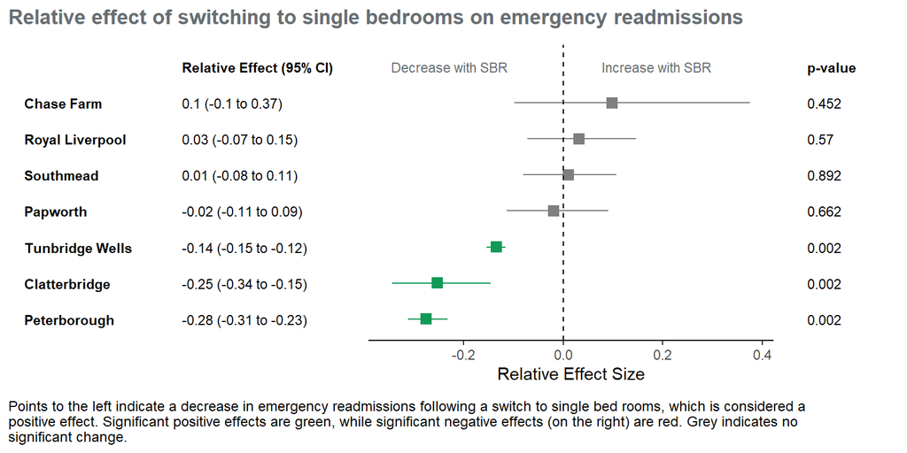

| Average effects of switching to single bedrooms on % of emergency readmissions Site | Average effects of switching to single bedrooms on % of emergency readmissions Actual Effect | Average effects of switching to single bedrooms on % of emergency readmissions Predicted Effect (95% CI) | Average effects of switching to single bedrooms on % of emergency readmissions Absolute Effect (95% CI) | Average effects of switching to single bedrooms on % of emergency readmissions Relative Effect (95% CI) | Average effects of switching to single bedrooms on % of emergency readmissions p-value | Average effects of switching to single bedrooms on % of emergency readmissions Significance |
| --- | --- | --- | --- | --- | --- | --- |
| Chase Farm | 7.68 | 7.04 (5.59 to 8.52) | 0.64 (-0.83 to 2.09) | 0.1 (-0.1 to 0.37) | 0.452 | Non-sig |
| Royal Liverpool | 50.97 | 49.54 (44.47 to 54.95) | 1.43 (-3.98 to 6.5) | 0.03 (-0.07 to 0.15) | 0.57 | Non-sig |
| Southmead | 26.37 | 26.16 (23.81 to 28.68) | 0.21 (-2.3 to 2.56) | 0.01 (-0.08 to 0.11) | 0.892 | Non-sig |
| Papworth | 12.00 | 12.27 (11.01 to 13.55) | -0.26 (-1.55 to 1) | -0.02 (-0.11 to 0.09) | 0.662 | Non-sig |
| Tunbridge Wells | 26.05 | 30.11 (29.47 to 30.78) | -4.06 (-4.73 to -3.42) | -0.14 (-0.15 to -0.12) | 0.002 | Sig Decrease |
| Clatterbridge | 25.04 | 33.65 (29.31 to 38.17) | -8.61 (-13.13 to -4.27) | -0.25 (-0.34 to -0.15) | 0.002 | Sig Decrease |
| Peterborough | 24.85 | 34.32 (32.39 to 36.11) | -9.47 (-11.26 to -7.54) | -0.28 (-0.31 to -0.23) | 0.002 | Sig Decrease |

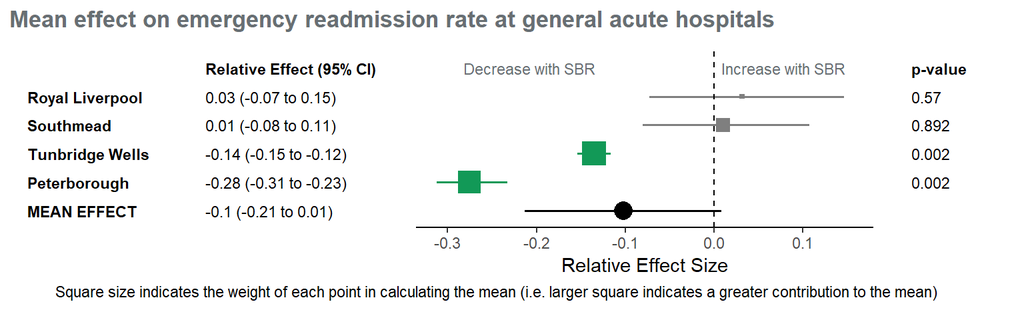

The emergency readmission rate was either unchanged or decreased by up to 28%. The mean effect at general acute hospitals was a non-significant 10% reduction in emergency readmissions. At Peterborough the percentage of emergency readmissions was predicted to be 34% but dropped to 25% following a switch to single bedrooms, while at Tunbridge Wells it was predicted to be 30% and dropped to 26% (Section 12.1.4).

### Cleaning costs

The cleaning costs (in £) per square metre of occupied floor space significantly decreased at 2/3 sites (Clatterbridge and Papworth) but were unchanged at 1/3 sites (Royal Liverpool).

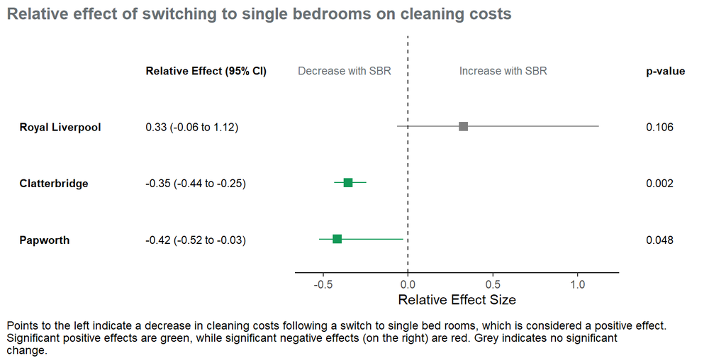

| Average effects of switching to single bedrooms on cleaning costs (£) per sqm Site | Average effects of switching to single bedrooms on cleaning costs (£) per sqm Actual Effect | Average effects of switching to single bedrooms on cleaning costs (£) per sqm Predicted Effect (95% CI) | Average effects of switching to single bedrooms on cleaning costs (£) per sqm Absolute Effect (95% CI) | Average effects of switching to single bedrooms on cleaning costs (£) per sqm Relative Effect (95% CI) | Average effects of switching to single bedrooms on cleaning costs (£) per sqm p-value | Average effects of switching to single bedrooms on cleaning costs (£) per sqm Significance |
| --- | --- | --- | --- | --- | --- | --- |
| Royal Liverpool | 56.44 | 44.18 (26.56 to 60.3) | 12.26 (-3.86 to 29.88) | 0.33 (-0.06 to 1.12) | 0.106 | Non-sig |
| Clatterbridge | 32.75 | 50.91 (43.48 to 58.06) | -18.16 (-25.31 to -10.74) | -0.35 (-0.44 to -0.25) | 0.002 | Sig Decrease |
| Papworth | 32.78 | 53.98 (33.54 to 68.63) | -21.2 (-35.85 to -0.76) | -0.42 (-0.52 to -0.03) | 0.048 | Sig Decrease |

Actual, Predicted and Absolute difference values expressed as £ per sqm

Cleaning costs decreased by 35% and 42% at Clatterbridge and Papworth, respectively (Section 12.1.5).

Cleaning costs are only recorded annually, so there is limited data with only 1 or 2 data points in the outcome period, and the first data point in the outcome period may not reflect the true changes in cost as some of the costs will have occurred prior to the switch, so these results should be interpreted cautiously.

## Health and Safety

### Deaths in hospital

The rate of in-hospital deaths (number per 1,000 discharges) significantly decreased at 1/5 sites (Peterborough) and was unchanged at 4/5 sites (Royal Liverpool, Tunbridge Wells, Clatterbridge and Southmead).

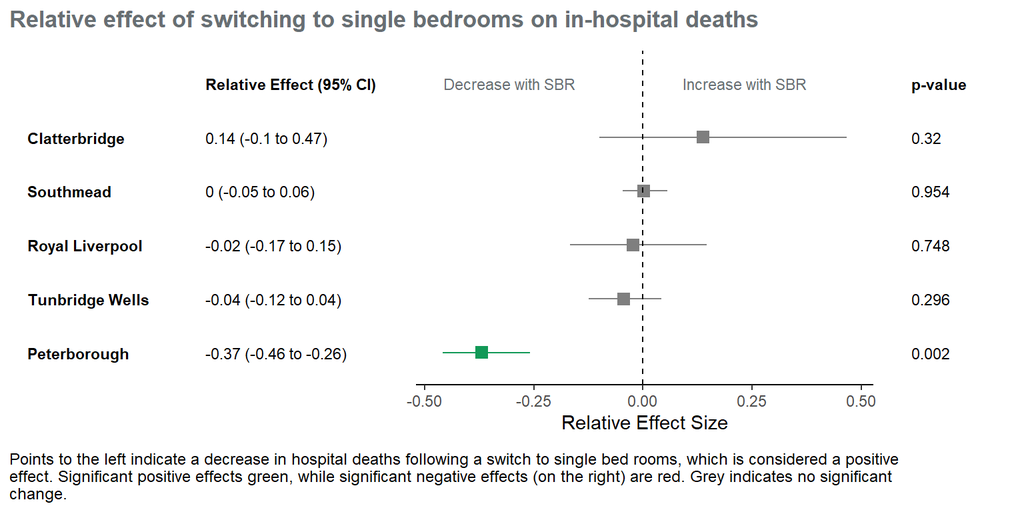

| Average effects of switching to single bedrooms on in-hospital deaths/1,000 discharges Site | Average effects of switching to single bedrooms on in-hospital deaths/1,000 discharges Actual Effect | Average effects of switching to single bedrooms on in-hospital deaths/1,000 discharges Predicted Effect (95% CI) | Average effects of switching to single bedrooms on in-hospital deaths/1,000 discharges Absolute Effect (95% CI) | Average effects of switching to single bedrooms on in-hospital deaths/1,000 discharges Relative Effect (95% CI) | Average effects of switching to single bedrooms on in-hospital deaths/1,000 discharges p-value | Average effects of switching to single bedrooms on in-hospital deaths/1,000 discharges Significance |
| --- | --- | --- | --- | --- | --- | --- |
| Clatterbridge | 85.80 | 76.41 (58.49 to 95.41) | 9.39 (-9.61 to 27.31) | 0.14 (-0.1 to 0.47) | 0.32 | Non-sig |
| Southmead | 25.87 | 25.81 (24.5 to 27.14) | 0.05 (-1.27 to 1.37) | 0 (-0.05 to 0.06) | 0.954 | Non-sig |
| Royal Liverpool | 37.37 | 38.46 (32.6 to 44.87) | -1.09 (-7.5 to 4.78) | -0.02 (-0.17 to 0.15) | 0.748 | Non-sig |
| Tunbridge Wells | 18.06 | 18.9 (17.34 to 20.63) | -0.84 (-2.56 to 0.73) | -0.04 (-0.12 to 0.04) | 0.296 | Non-sig |
| Peterborough | 23.96 | 38.29 (32.35 to 44.27) | -14.33 (-20.3 to -8.39) | -0.37 (-0.46 to -0.26) | 0.002 | Sig Decrease |

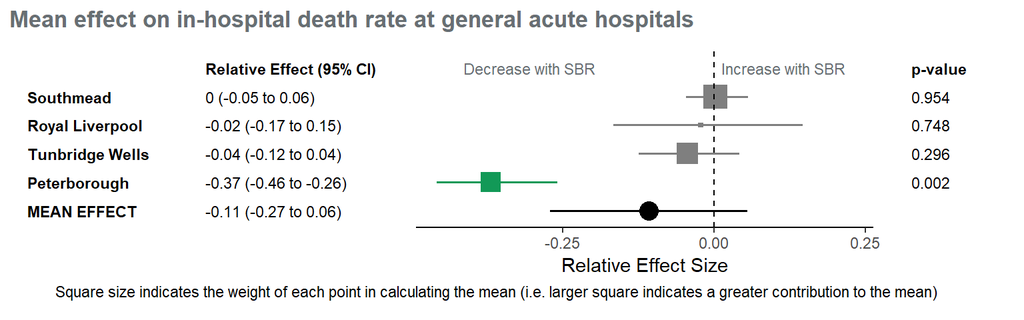

In-hospital deaths were generally unchanged but decreased by 37% at Peterborough (Section 12.1.6). The 37% decrease at Peterborough reflects a decrease from a predicted 38 deaths per 1,000 discharges to 24 deaths. The mean effect at general acute hospitals was a non-significant decrease of 11% in in-hospital death.

### Falls and injuries in hospital

The rate of in-hospital falls and injuries (% of spells) significantly decreased at 1/4 sites (Peterborough), and was unchanged at 3/4 sites (Royal Liverpool, Tunbridge Wells and Southmead).

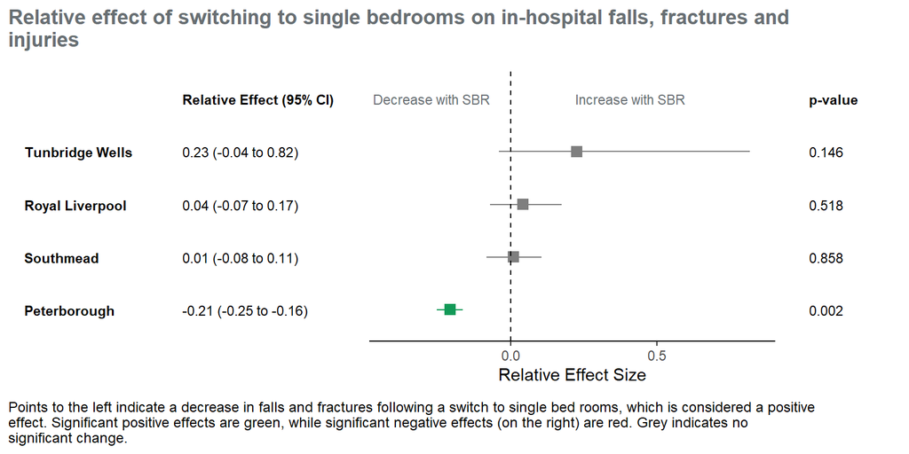

| Average effects of switching to single bedrooms on % of spells with in-hospital fall or injury Site | Average effects of switching to single bedrooms on % of spells with in-hospital fall or injury Actual Effect | Average effects of switching to single bedrooms on % of spells with in-hospital fall or injury Predicted Effect (95% CI) | Average effects of switching to single bedrooms on % of spells with in-hospital fall or injury Absolute Effect (95% CI) | Average effects of switching to single bedrooms on % of spells with in-hospital fall or injury Relative Effect (95% CI) | Average effects of switching to single bedrooms on % of spells with in-hospital fall or injury p-value | Average effects of switching to single bedrooms on % of spells with in-hospital fall or injury Significance |
| --- | --- | --- | --- | --- | --- | --- |
| Tunbridge Wells | 1.05 | 0.88 (0.58 to 1.09) | 0.17 (-0.04 to 0.47) | 0.23 (-0.04 to 0.82) | 0.146 | Non-sig |
| Royal Liverpool | 3.43 | 3.31 (2.92 to 3.69) | 0.13 (-0.26 to 0.51) | 0.04 (-0.07 to 0.17) | 0.518 | Non-sig |
| Southmead | 1.60 | 1.58 (1.44 to 1.74) | 0.01 (-0.15 to 0.15) | 0.01 (-0.08 to 0.11) | 0.858 | Non-sig |
| Peterborough | 2.54 | 3.21 (3.04 to 3.41) | -0.67 (-0.87 to -0.5) | -0.21 (-0.25 to -0.16) | 0.002 | Sig Decrease |

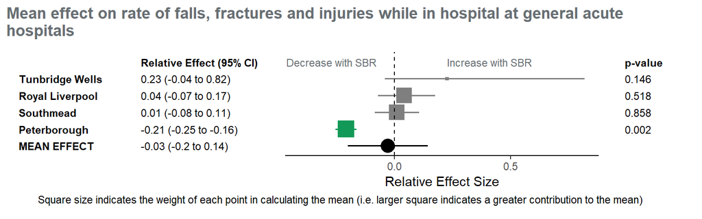

The in-hospital falls and injuries rate was generally unchanged, but decreased by 21% at Peterborough (Section 12.1.7). The 21% decrease at Peterborough reflects a decrease from a predicted 3.2% of hospital spells having a fall or injury to 2.5%. The mean effect at general acute hospitals was a non-significant 3% reduction in the rate of in-hospital falls, injuries and fractures.

### Healthcare acquired c.difficile infections

The rate of healthcare acquired C. difficile infections (cases per 10,000 bed days) decreased at 2/3 sites (Chase Farm and Southmead) but was unchanged at Royal Liverpool.

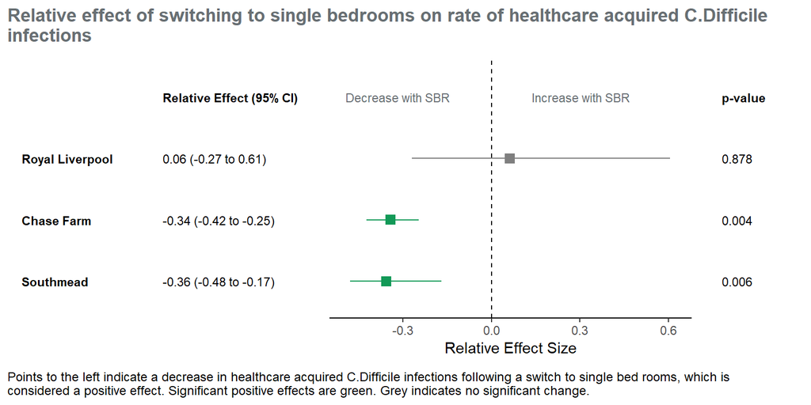

| Average effects of switching to single bedrooms on cases of healthcare acquired C.Difficile infections /10,000 bed days Site | Average effects of switching to single bedrooms on cases of healthcare acquired C.Difficile infections /10,000 bed days Actual Effect | Average effects of switching to single bedrooms on cases of healthcare acquired C.Difficile infections /10,000 bed days Predicted Effect (95% CI) | Average effects of switching to single bedrooms on cases of healthcare acquired C.Difficile infections /10,000 bed days Absolute Effect (95% CI) | Average effects of switching to single bedrooms on cases of healthcare acquired C.Difficile infections /10,000 bed days Relative Effect (95% CI) | Average effects of switching to single bedrooms on cases of healthcare acquired C.Difficile infections /10,000 bed days p-value | Average effects of switching to single bedrooms on cases of healthcare acquired C.Difficile infections /10,000 bed days Significance |
| --- | --- | --- | --- | --- | --- | --- |
| Royal Liverpool | 2.45 | 2.39 (1.52 to 3.36) | 0.06 (-0.91 to 0.92) | 0.06 (-0.27 to 0.61) | 0.878 | Non-sig |
| Chase Farm | 2.65 | 4.04 (3.52 to 4.6) | -1.39 (-1.95 to -0.87) | -0.34 (-0.42 to -0.25) | 0.004 | Sig Decrease |
| Southmead | 1.33 | 2.09 (1.6 to 2.55) | -0.76 (-1.22 to -0.27) | -0.36 (-0.48 to -0.17) | 0.006 | Sig Decrease |

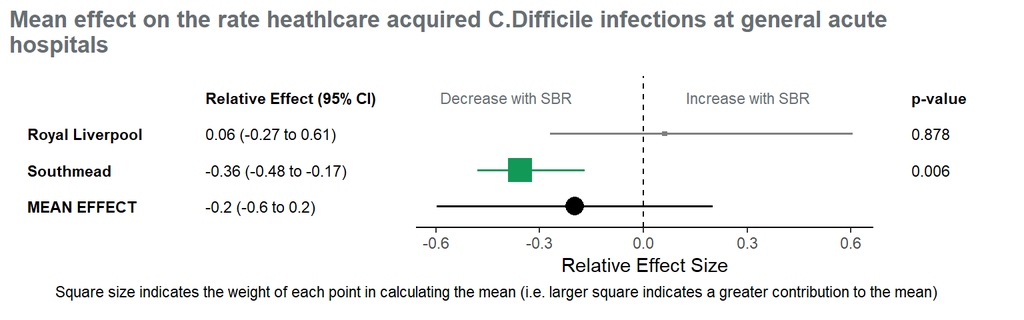

The rate of healthcare acquired C. difficile was either unchanged or decreased by up to 36% (Section 12.1.8). The 36% decrease in C.diff infections at Southmead reflects a decrease from a predicted 2.1 cases per 10,000 beddays to 1.3 cases. The mean effect at general acute hospitals was a non-significant 20% reduction in the rate of C. difficile infections.

## Patient and Staff Experience

### Patient experience - Friends and Family Test

Patient experience was determined using the results of the Friends and Family test. The percentage of positive responses significantly decreased at 1/5 sites (Clatterbridge), increased at 1/5 sites (Papworth) and was unchanged at the other 3/5 sites (Royal Liverpool, Southmead and Chase Farm).

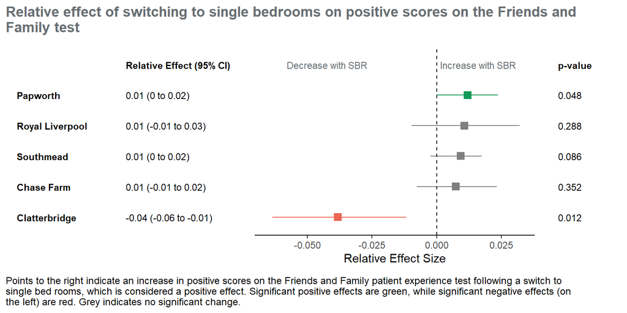

| Average effects of switching to single bedrooms on % of positive responses on the Friends and Family test Site | Average effects of switching to single bedrooms on % of positive responses on the Friends and Family test Actual Effect | Average effects of switching to single bedrooms on % of positive responses on the Friends and Family test Predicted Effect (95% CI) | Average effects of switching to single bedrooms on % of positive responses on the Friends and Family test Absolute Effect (95% CI) | Average effects of switching to single bedrooms on % of positive responses on the Friends and Family test Relative Effect (95% CI) | Average effects of switching to single bedrooms on % of positive responses on the Friends and Family test p-value | Average effects of switching to single bedrooms on % of positive responses on the Friends and Family test Significance |
| --- | --- | --- | --- | --- | --- | --- |
| Papworth | 97.92 | 96.76 (95.65 to 97.91) | 1.16 (0.01 to 2.27) | 0.01 (0 to 0.02) | 0.048 | Sig Increase |
| Royal Liverpool | 91.41 | 90.43 (88.56 to 92.3) | 0.98 (-0.9 to 2.85) | 0.01 (-0.01 to 0.03) | 0.288 | Non-sig |
| Southmead | 95.06 | 94.18 (93.43 to 95.28) | 0.88 (-0.22 to 1.63) | 0.01 (0 to 0.02) | 0.086 | Non-sig |
| Chase Farm | 94.82 | 94.09 (92.67 to 95.56) | 0.73 (-0.73 to 2.16) | 0.01 (-0.01 to 0.02) | 0.352 | Non-sig |
| Clatterbridge | 93.87 | 97.61 (94.99 to 100.24) | -3.74 (-6.37 to -1.12) | -0.04 (-0.06 to -0.01) | 0.012 | Sig Decrease |

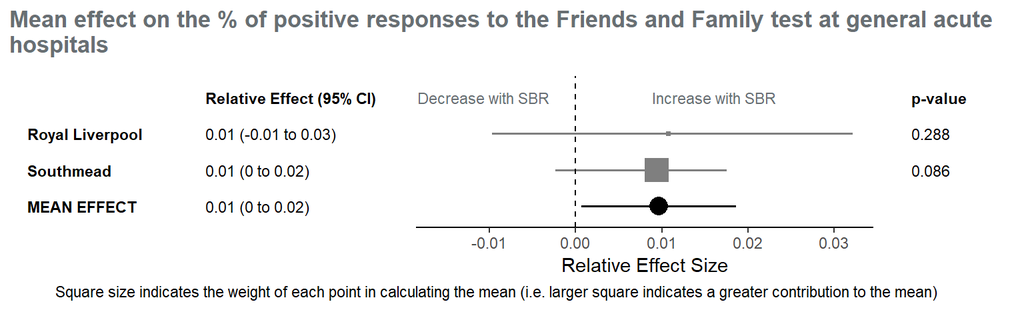

The effect on the percentage of positive responses to the Friend and Family Test was mixed; the percentage of positive responses increased by 1% at Papworth, but decreased by 4% at Clatterbridge (Section 12.1.9). It should be noted that based on historic trends Clatterbridge was predicted to have over 97% of positive responses, so although there was a small decrease the percentage of positive responses remained at almost 94%, which is broadly similar to that seen at the other study sites.

For the general acute hospitals the mean effect was a statistically significant 1% increase in positive responses to the Friends and Family test.

It should be noted that due to the COVID-19 pandemic there is missing friends and family test scores data from March 2020 until late 2020/early 2021 for all sites. Therefore, both Papworth and Clatterbridge have missing data in their outcome periods.

### Staff sickness

The percentage of available days taken off sick by staff significantly increased at 2/7 sites (Southmead and Tunbridge Wells) and was unchanged at the remaining 5 sites.

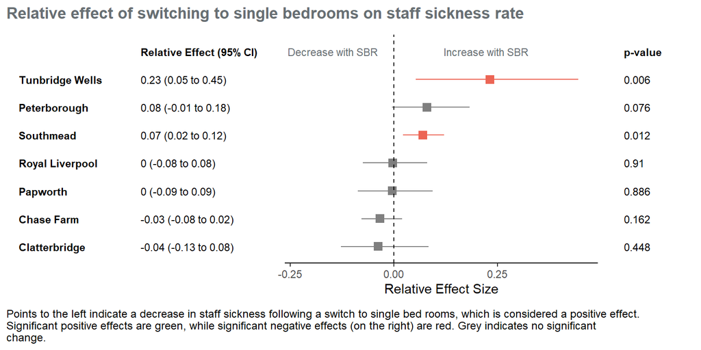

| Average effects of switching to single bedrooms on staff sickness rate (% of available days) Site | Average effects of switching to single bedrooms on staff sickness rate (% of available days) Actual Effect | Average effects of switching to single bedrooms on staff sickness rate (% of available days) Predicted Effect (95% CI) | Average effects of switching to single bedrooms on staff sickness rate (% of available days) Absolute Effect (95% CI) | Average effects of switching to single bedrooms on staff sickness rate (% of available days) Relative Effect (95% CI) | Average effects of switching to single bedrooms on staff sickness rate (% of available days) p-value | Average effects of switching to single bedrooms on staff sickness rate (% of available days) Significance |
| --- | --- | --- | --- | --- | --- | --- |
| Tunbridge Wells | 3.63 | 2.96 (2.51 to 3.45) | 0.66 (0.18 to 1.12) | 0.23 (0.05 to 0.45) | 0.006 | Sig Increase |
| Peterborough | 3.57 | 3.32 (3.02 to 3.59) | 0.26 (-0.02 to 0.55) | 0.08 (-0.01 to 0.18) | 0.076 | Non-sig |
| Southmead | 4.64 | 4.34 (4.14 to 4.54) | 0.3 (0.1 to 0.5) | 0.07 (0.02 to 0.12) | 0.012 | Sig Increase |
| Royal Liverpool | 6.34 | 6.36 (5.87 to 6.86) | -0.03 (-0.52 to 0.47) | 0 (-0.08 to 0.08) | 0.91 | Non-sig |
| Papworth | 3.77 | 3.79 (3.45 to 4.13) | -0.02 (-0.36 to 0.32) | 0 (-0.09 to 0.09) | 0.886 | Non-sig |
| Chase Farm | 3.64 | 3.77 (3.57 to 3.95) | -0.13 (-0.31 to 0.07) | -0.03 (-0.08 to 0.02) | 0.162 | Non-sig |
| Clatterbridge | 4.91 | 5.11 (4.53 to 5.63) | -0.21 (-0.72 to 0.38) | -0.04 (-0.13 to 0.08) | 0.448 | Non-sig |

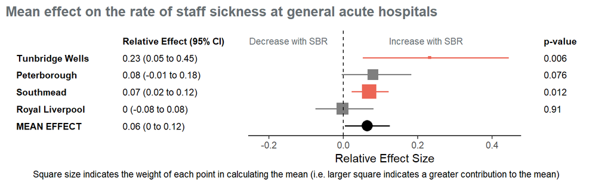

Staff sickness rates generally remained unchanged, but there was a 7% increase at Southmead and 23% increase at Tunbridge Wells (Section 12.1.10). The mean effect at general acute hospitals was a significant increase of 6% in the staff sickness rate. Although staff sickness did remain unchanged at the three specialist sites.

While there was a significant increase in staff sickness at Southmead (average of 4.6% of available days taken as sick days compared to a predicted 4.3%) this seems to have been a temporary effect. The sickness rate is increased in the first year after the switch to single bedrooms and during this period there is a significantly larger winter peak. In the second year of the outcome period staff sickness rates fell back in line with the expected rates. A similar, albeit non-significant, effect is seen at Peterborough with a larger winter spike in the first year of the outcome period before sickness levels return to expected levels.

### Staff turnover

Staff turnover measured as percentage of staff leaving was not significantly changed at any of the three sites where data was available (Section 12.1.11).

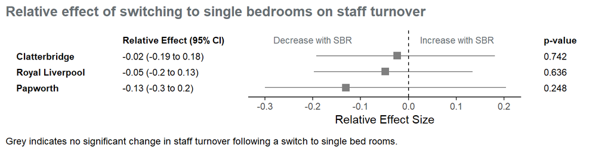

| Average effects of switching to single bedrooms on rate of staff turnover (% leaving) Site | Average effects of switching to single bedrooms on rate of staff turnover (% leaving) Actual Effect | Average effects of switching to single bedrooms on rate of staff turnover (% leaving) Predicted Effect (95% CI) | Average effects of switching to single bedrooms on rate of staff turnover (% leaving) Absolute Effect (95% CI) | Average effects of switching to single bedrooms on rate of staff turnover (% leaving) Relative Effect (95% CI) | Average effects of switching to single bedrooms on rate of staff turnover (% leaving) p-value | Average effects of switching to single bedrooms on rate of staff turnover (% leaving) Significance |
| --- | --- | --- | --- | --- | --- | --- |
| Clatterbridge | 12.13 | 12.55 (10.27 to 15.03) | -0.42 (-2.9 to 1.86) | -0.02 (-0.19 to 0.18) | 0.742 | Non-sig |
| Royal Liverpool | 9.20 | 9.76 (8.11 to 11.47) | -0.56 (-2.27 to 1.09) | -0.05 (-0.2 to 0.13) | 0.636 | Non-sig |
| Papworth | 12.64 | 14.8 (10.5 to 18.05) | -2.16 (-5.41 to 2.14) | -0.13 (-0.3 to 0.2) | 0.248 | Non-sig |

### Staff survey

To assess staff experience the NHS staff survey was used and we analysed the percentage of staff that Agreed or Strongly Agreed with the statement ‘I would recommend my trust as a place to work’.

The percentage of staff that would recommend their trust as a place to work significantly increased at 1/6 sites (Papworth) and was unchanged at 3/6 (Chase Farm, Royal Liverpool and Tunbridge Wells). At 2/6 sites (Southmead and Clatterbridge) there was a significant decrease in the percentage that would recommend their trust as a place to work.

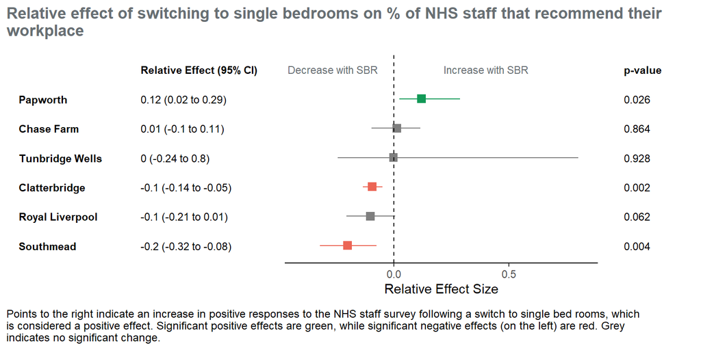

| Average effects of switching to single bedrooms on % of NHS staff who would recommend their workplace Site | Average effects of switching to single bedrooms on % of NHS staff who would recommend their workplace Actual Effect | Average effects of switching to single bedrooms on % of NHS staff who would recommend their workplace Predicted Effect (95% CI) | Average effects of switching to single bedrooms on % of NHS staff who would recommend their workplace Absolute Effect (95% CI) | Average effects of switching to single bedrooms on % of NHS staff who would recommend their workplace Relative Effect (95% CI) | Average effects of switching to single bedrooms on % of NHS staff who would recommend their workplace p-value | Average effects of switching to single bedrooms on % of NHS staff who would recommend their workplace Significance |
| --- | --- | --- | --- | --- | --- | --- |
| Papworth | 67.44 | 60.46 (52.39 to 65.87) | 6.98 (1.56 to 15.05) | 0.12 (0.02 to 0.29) | 0.026 | Sig Increase |
| Chase Farm | 62.47 | 61.94 (56.04 to 69.22) | 0.54 (-6.75 to 6.44) | 0.01 (-0.1 to 0.11) | 0.864 | Non-sig |
| Tunbridge Wells | 60.28 | 59.12 (33.38 to 78.25) | 1.16 (-17.97 to 26.9) | 0 (-0.24 to 0.8) | 0.928 | Non-sig |
| Clatterbridge | 64.33 | 71.18 (67.76 to 74.42) | -6.85 (-10.09 to -3.43) | -0.1 (-0.14 to -0.05) | 0.002 | Sig Decrease |
| Royal Liverpool | 50.32 | 56.31 (50.04 to 63.41) | -5.99 (-13.09 to 0.28) | -0.1 (-0.21 to 0.01) | 0.062 | Non-sig |
| Southmead | 45.07 | 56.83 (48.74 to 66.58) | -11.77 (-21.51 to -3.68) | -0.2 (-0.32 to -0.08) | 0.004 | Sig Decrease |

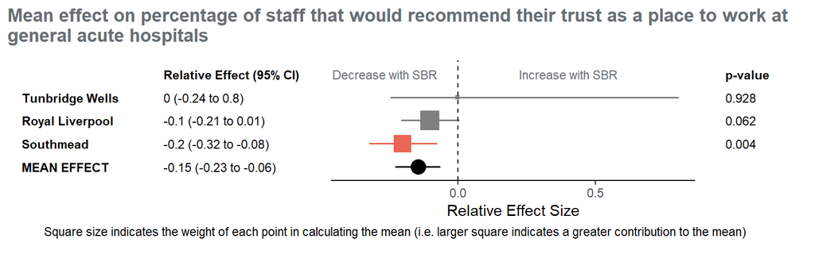

The effect on the percentage of staff that would recommend their workplace varied from a 20% decrease to a 12% increase (Section 12.1.12). At Southmead the 20% reduction in the percentage of staff recommending their workplace equates to a reduction from a predicted percentage of 57% recommending their workplace to 45% following the switch to single bedrooms. The mean effect at general acute hospitals was a significant reduction of 15% in the percentage of staff who would recommend their workplace.

At Southmead the decrease appears to be temporary, occurring in the first year post-switch to single bed rooms with positive responses increasing back to the expected level in the second year of the outcome period.

The staff survey is an annual measure so there is limited data, with only 1 or 2 data points in the outcome period. The staff survey data is collected over a period of time in the autumn each year, but for analysis purposes we have set the date as the last day of the year in which the data was collected. Both Chase Farm and Royal Liverpool switched to single rooms during the autumn, so the data for the first data point in the outcome period would actually have been collected during the transition period which may have had an impact on the results.

## Summary of results

|  | Royal Liverpool | Clatterbridge | Papworth | Chase Farm | Southmead | Tunbridge Wells | Peterborough |
| --- | --- | --- | --- | --- | --- | --- | --- |
| Productivity & Efficiency |  |  |  |  |  |  |  |
| Length of stay | - | ↑ |  | ↓ | ↓ | - | ↓ |
| Waiting time | ↓ | - | - |  |  | ↑ | ↓ |
| Bed occupancy | - | ↑ |  | - | ↑ |  |  |
| Emergency readmissions | - | ↓ | - | - | - | ↓ | ↓ |
| Cleaning costs | - | ↓ | ↓ |  |  |  |  |
| Health & Safety |  |  |  |  |  |  |  |
| Hospital deaths | - | - |  |  | - | - | ↓ |
| Falls and injuries | - |  |  |  | - | - | ↓ |
| Healthcare acquired C.diff | - |  |  | ↓ | ↓ |  |  |
| Patient & Staff experience |  |  |  |  |  |  |  |
| Patient experience | - | ↓ | ↑ | - | - |  |  |
| Staff sickness | - | - | - | - | ↑ | ↑ | - |
| Staff turnover | - | - | - |  |  |  |  |
| Staff survey | - | ↓ | ↑ | - | ↓ | - |  |

↑ indicates a significant increase post-switch to single rooms, while ↓ indicates a significant decrease. Where a result is considered positive, e.g. decreased length of stay or increased patient experience score, it is coloured green, while a negative result is shown in red. '-' indicates a non-significant change, which is shown in yellow. Grey shading indicates where there was insufficient data to analyse.

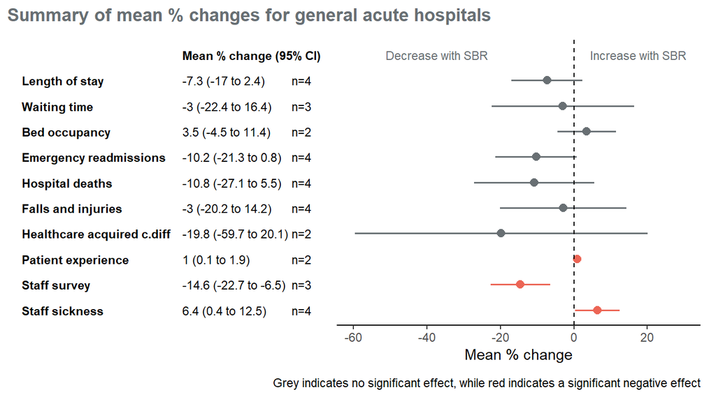

The impact of switching to single bedrooms appears to vary depending on the hospital site. The switch at Peterborough has generally resulted in positive impacts, while the switch at Clatterbridge has been a little more negative. It should be noted that in some cases where negative outcomes are seen these are transient changes or there are others factors that may be influencing the results. For example, Clatterbridge switched to single bed rooms during the high of the COVID-19 pandemic and indeed its opening was brought forward as a result of the pandemic, which may have impacted outcomes.

Generally, following a switch to single bedrooms the productivity and efficiency measures are showing trends towards positive impacts. While overall at general acute hospitals there are no significant changes, the data trends towards a decrease in mean length of stay and rate of emergency readmissions and increase in bed occupancy. For median waiting time there is also no significant change overall, but results will be complicated by the dynamic nature of waiting lists, where list size not only depends on productivity but also the number of referrals, which may change with a new hospital site. Data for cleaning costs is very limited and the results are mixed.

Switching to single bedrooms appears to have a positive or neutral effect on Health and Safety measures. It could be considered that no change in health and safety measures is a positive effect, as patient safety does not appear to be negatively impacted, which has been raised as a concern due to patients being potentially less visible to staff when in single bedrooms. While our data on hospital acquired infections is very limited, there is a trend towards a decrease in C. difficile infections. At some hospital sites, such as Papworth, the rates of C.difficile rates were so low it was not possible to fit a suitable causal impact model; given the hospitals have already have very low rates it could be concluded that it would be unlikely that the rates could be further reduced by a meaningful amount.

In terms of patient and staff experiences the switch to single bedrooms has had a generally negative effect for staff. For general acute hospitals there was a significant reduction of 15% in the percentage of staff who would recommend their trust as a place to work and a significant 6% increase in staff sickness. Some of these negative effects are seen primarily in the first year post-switch before returning to expected levels during the second year. This initial negative impact may be associated with uncertainty, initial concerns over or difficulties adapting to the new design, or it may be that after time changes in policies and procedures have been introduced to mitigate the negative impacts on staff. Some staff may be negatively impacted simply by a switch to a new site, regardless of whether it has single bed rooms, due to factors such as longer or more complex travel to the new hospital site. There was an increase in staff sickness, suggesting that staff are not better protected from contracting infections from patients in single room hospitals, but that potentially staff could be having increased sickness potentially related to musculoskeletal issues and stress (SF Søndergaard 2022). There is a small but statistically significant increase of 1% in the percentage of patients reporting a positive experience.

# Limitations and discussion

**Data quality and availability**

Our analyses rely on historical data collections, some of which do not go back as far as 2008 (see Figure 1). There are also gaps/anomalous data in the time series for some providers and potential control sites. How some metrics have been measured is likely to have changed over time, but the causal impact analysis uses control data from sites without interventions which will help to correct for any changes occurring at all sites. Some study sites have been involved in trust mergers/site changes in the time period prior to switching to single bedrooms; we have merged historic data where appropriate, but these mergers may have impacted the time series.

Some variables are only available at provider level (Table 3), so where providers have more than one site any change that may occur following a switch to single bedrooms at one site will be diluted by a lack of change at the providers other sites.

The variables that we have measured are not always entirely specific to the impact we are trying to measure, for example we are using both staff sickness and staff turnover as a proxy for staff experience, with the assumption that increased staff turnover and sickness absences could indicate that staff are less happy in their workplace following a switch to single bedrooms. It is possible that sickness absences may be influenced in other ways by a switch to single bedrooms, for example if single bedrooms reduce outbreaks of contagious illnesses such as influenza and better protect staff from contracting them themselves, then sickness absences could be reduced. Indeed, the staff and patient surveys will influenced by many other factors not just single bed rooms. Median waiting time is used as a proxy for how productive a hospital is, but waiting times will depend on not only the flow of patients through the hospital, but the numbers being referred. If a new hospital gets a large increase in referrals then even with an moderate increase in productivity there could still be an increase in waiting times as the waiting list size grows.

Some measures are recorded quarterly (bed occupancy) or annually (cleaning costs and staff survey) so we have less data points with which to fit our models and assess outcomes, and less temporal specificity to detect changes.

COVID-19 has impacted many of the variables for sites that switched just before or after the onset of the pandemic (Royal Liverpool, Clatterbridge and Papworth). While the causal impact analysis does use control sites to account for changes over time that would have happened without the intervention, the magnitude of the impact of the COVID-19 was sometimes different between study sites and their controls. Papworth, in particular, appeared to be more impacted by COVID-19 than its control sites.

**Model fit and methodology**

Model fit was assessed using the Mean Absolute Percentage Error (MAPE) and Durbin-Watson statistic, and adjustments were made to try to ensure a good historical model fit while minimising the forecasting intervals. However, for some data the models will be a less good fit and will have large credible intervals in the outcome period due to the variability in the indicator not being well explained by the control time series.

Three of the seven study sites were specialist sites (Papworth is a specialist cardiothoracic/transplant centre, Clatterbridge is a cancer centre and Chase Farm only conducts elective care), making it more difficult to select well matched control sites. The number of sites in the control pool was very limited for both Clatterbridge (4) and Papworth (9), which may impact the quality of the model fit and reliability of the outcomes.

The three specialist provider sites were excluded from the meta-analysis as the impacts on these sites may be less generalisable to new general acute hospitals that may be built in the future. The meta-analyses were weighted based on the inverse variance of the relative effects, but other factors that may influence how much weight should be given to a particular site were not included.

**General**

For our analysis we have had to specify the month in which the switch to single bedrooms occurred. However, at some sites the switch was done over a longer period of time with certain services moving at different stages. For example, Tunbridge Wells moved Women and Children’s wards to single bed rooms in January 2011 and the remainder of inpatient services in September 2011. We have used the month when the switch started, so that control site selection and predictions are not affected by changes in the transition period, but this means that we may see initial changes related to the transition period or that some changes may not be seen until later in the outcome period when the full switch had occurred.

When the sites switched to single bedrooms there are likely to have been other changes to how services operate and at multi-site providers there may also have been changes to what services are provided at which sites, so there are likely to be confounding factors that influence our results.

Not all sites switched entirely to single bed rooms and all sites had differing proportions of single bedrooms prior to the switch. There does not appear to be a clear relationship between the percentage of single bedrooms post switch or the change in proportion of single bed and the varying outcomes that are seen at individual sites. The sites that switched to single bedrooms will have had different designs and the differences in results between sites may be due to different single bedroom designs/implementation working better, or worse, than others. It is also possible that the best design/impementation may vary by hospital type so that a design that suits a general acute hospital may work less well at a specialist site. Where there are potential negative impacts of a switch to single bedrooms some sites may have had mitigating factors in place from the start while other schemes may have brought in mitigating factors at a later date once issues had already arisen.

We see some limited evidence that the rate of hospital acquired C. difficile infections may be reduced, but unfortunately it was not possible to assess other healthcare acquired infections (MSSA, MRSA, Klebsiella and P. aeruginosa) due to a lack of data availability before 2017. In addition, there is no data on other hospital acquired contagious illnesses, such as influenza and COVID-19, where the spread may be reduced by single bed rooms. It is possible that due to en suite bathrooms in single bedroom hospitals, that there is an increased risk of Legionella, due to increased pipework and bathrooms potentially not all being used regularly.

The following table are a subjective rating of our confidence in the indicators to assess the impacts of SBR given the above caveats and limitations:

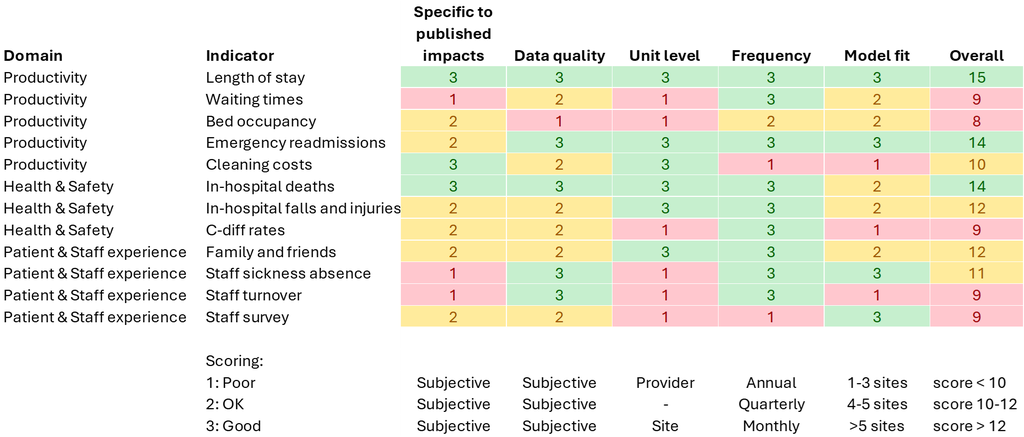

Further notes on data quality and reasons for exclusion of sites from indicator analysis are in Section 12.2.

# Recommendations for modelling and future evaluation

While the availability of data has improved since 2008, there is a still a need to ensure consistent and accurate data recording at ideally a site level, in order to more accurately evaluate the impact of any future hospital designs.

Given the apparent negative impacts on staff of a switch to single bedrooms it is likely important going forward that more data is collected on the views of staff specifically around switching to single bedrooms, including qualitative data to better understand what concerns and difficulties there may be.

Also, more data is needed to fully understand the impacts of single bedrooms on infection control, including things such as hospital acquired influenza or COVID-19.

Further analysis would be needed to fully understand the impact on waiting times and waiting list sizes, given the dynamic nature of waiting lists. This is a measure where there could be cumulative effects over time, and also a new or redesigned hospital could result in more or less people being referred, so waiting list size/time will not just be dependent on hospital productivity.

Future work should focus on understanding how/whether outcomes in single room hospitals may be impacted by factors such as the layout and design of a hospital, culture, use of technology and ways of working. Additionally, for length of stay in particular, work to understand specialty or patient group impacts would support more specific modelling assumptions.

# Appendices

## A. CIA charts by indicator and hospital site/provider

### Length of stay

**Decrease**

Peterborough

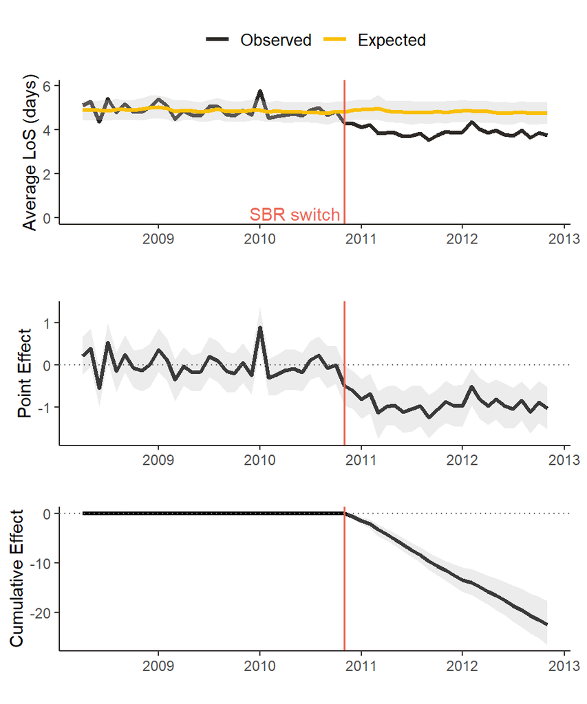

Chase Farm

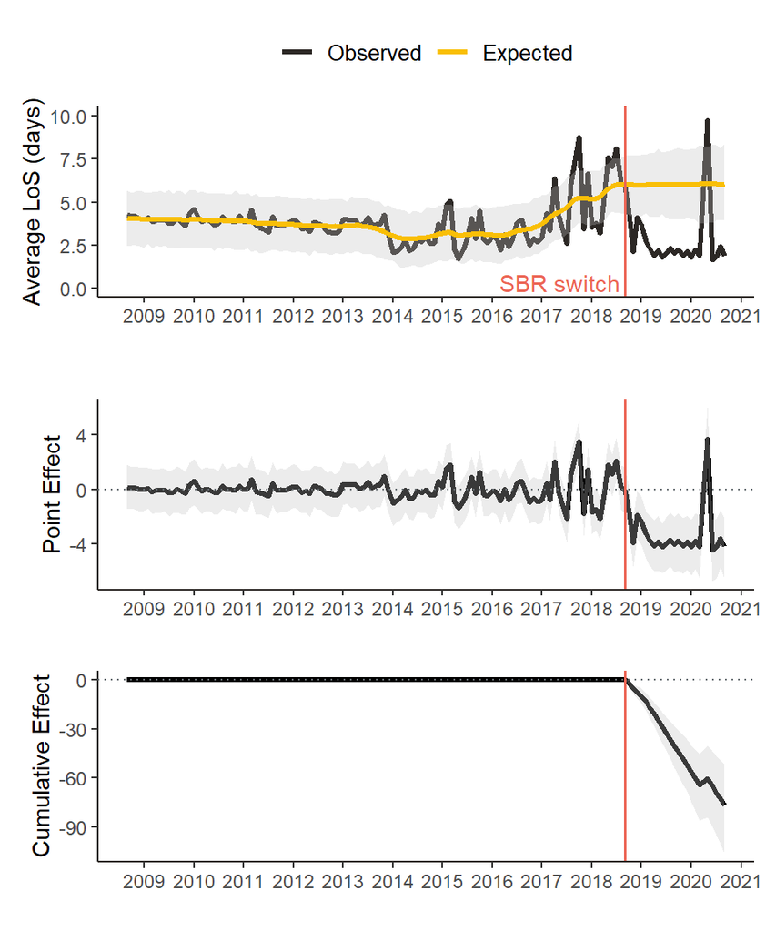

Southmead

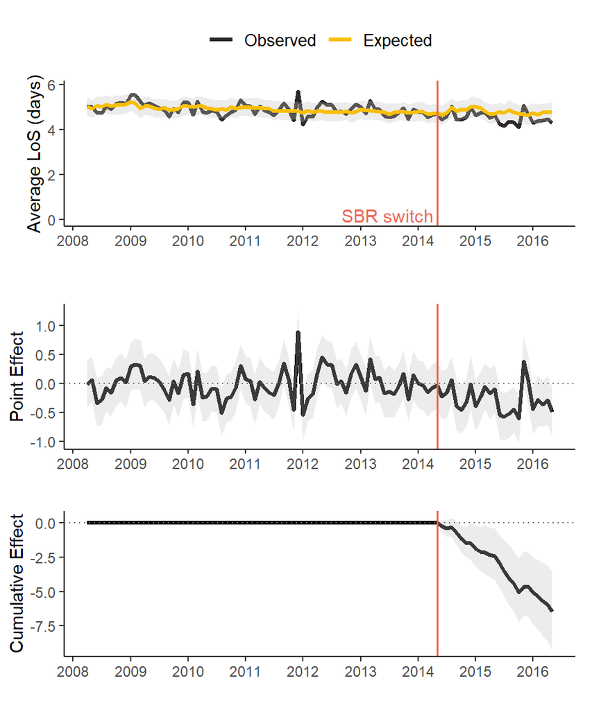

**No change**

Tunbridge Wells

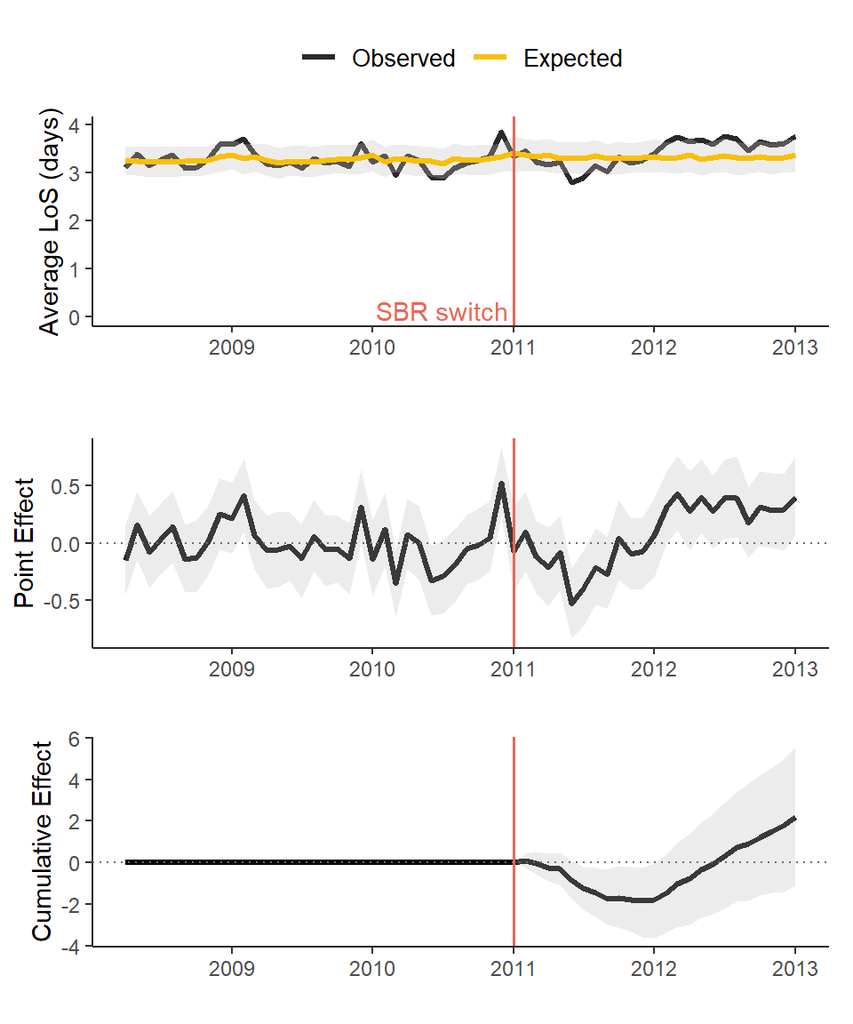

Royal Liverpool

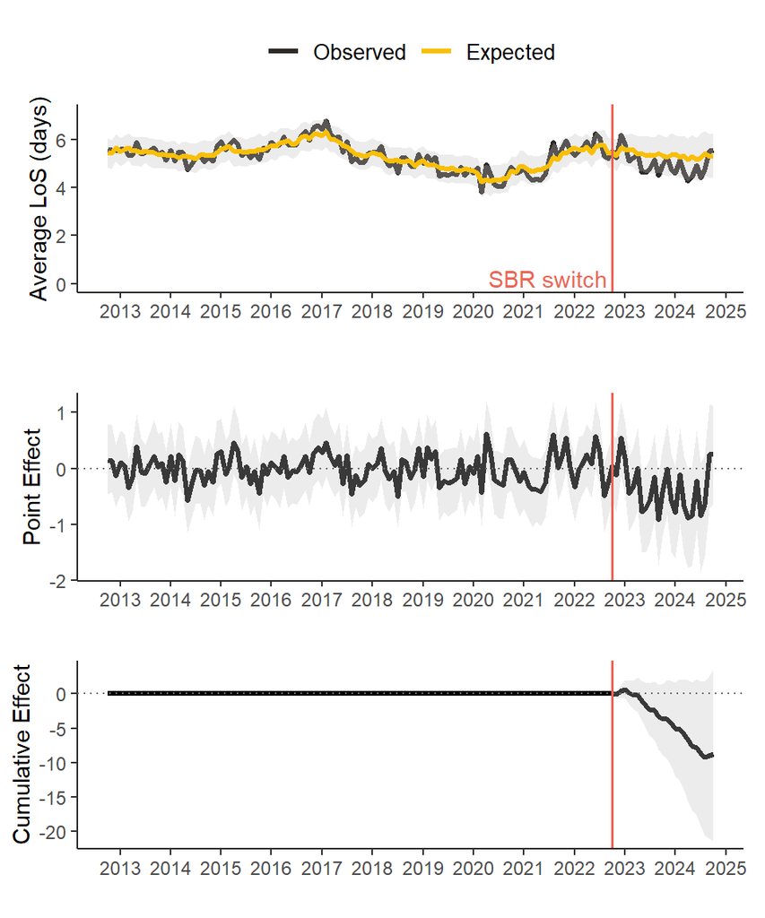

**Increase**

Clatterbridge

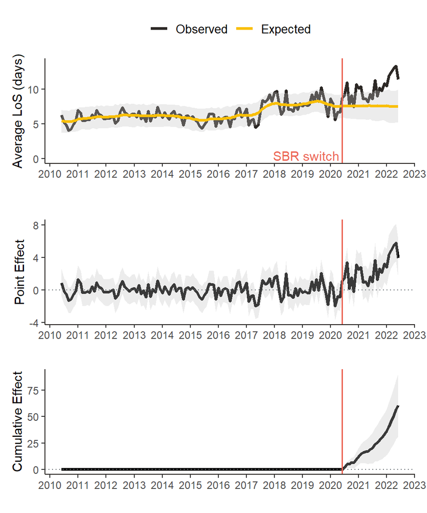